# Superficie forestal y trastornos mentales en las Comunidades Autónomas de España

2026-10-24

## Introducción

Los trastornos mentales constituyen uno de los principales retos de salud pública en la actualidad. Problemas como la depresión, la ansiedad y otros trastornos psicológicos afectan a millones de personas en todo el mundo, generando consecuencias importantes tanto a nivel individual como social. La aparición de estos trastornos depende de múltiples factores biológicos, sociales, económicos y ambientales, por lo que su estudio requiere un enfoque multidisciplinar.

En los últimos años ha aumentado el interés científico por comprender la influencia que los espacios naturales pueden ejercer sobre la salud mental. Diversas investigaciones sugieren que la exposición frecuente a entornos naturales puede contribuir a la reducción de los niveles de estrés, mejorar la capacidad de recuperación psicológica y favorecer el bienestar general de la población. Entre los posibles mecanismos implicados destacan la disminución de la exposición a factores estresantes propios de los entornos urbanos, la mejora de la calidad ambiental y la promoción de estilos de vida más saludables.

España presenta una gran diversidad territorial en cuanto a la distribución de espacios naturales. Algunas Comunidades Autónomas poseen una elevada proporción de superficie forestal, mientras que otras cuentan con una presencia considerablemente menor de este tipo de ecosistemas. Estas diferencias ofrecen una oportunidad interesante para analizar si existe alguna asociación entre la disponibilidad de espacios naturales y determinados indicadores relacionados con la salud mental.

En este contexto, el presente trabajo tiene como finalidad estudiar la posible relación entre el porcentaje de superficie forestal de las Comunidades Autónomas españolas y la prevalencia de diagnóstico de trastorno mental a lo largo de la vida. Además, se analizarán las diferencias observadas entre hombres y mujeres con el objetivo de determinar si el sexo puede influir en los patrones detectados. Mediante el uso de datos procedentes de fuentes oficiales, se pretende explorar si una mayor disponibilidad de espacios forestales podría estar asociada con una menor prevalencia de trastornos mentales en la población española.

## Objetivos

### Objetivo General

Investigar la posible asociación entre el porcentaje de superficie forestal y la prevalencia del diagnóstico de trastorno mental en las Comunidades Autónomas de España, con el fin de analizar si una mayor presencia de espacios naturales puede estar relacionada con mejores indicadores de salud mental. Asimismo, se evaluarán las diferencias observadas entre hombres y mujeres para determinar si el sexo influye en los patrones identificados y en la distribución territorial de los trastornos mentales.

### Objetivos Específicos

Describir la distribución de la superficie forestal en las Comunidades Autónomas de España.

- Analizar la prevalencia del diagnóstico de trastorno mental en las Comunidades Autónomas españolas, comparando las diferencias entre hombres y mujeres.
- Estudiar la posible relación entre la superficie forestal y la prevalencia de trastorno mental.
- Identificar patrones territoriales y posibles excepciones a la tendencia observada.

## Metodología

### Fuentes de datos

Para el desarrollo de este estudio se han utilizado dos fuentes principales de información, ambas relacionadas con el ámbito medioambiental y la salud pública en España. La combinación de estos conjuntos de datos permite explorar posibles asociaciones entre las características ambientales de las Comunidades Autónomas y determinados indicadores de salud mental, considerando también las diferencias existentes entre hombres y mujeres.

#### Datos sobre superficie forestal

La información medioambiental se ha obtenido del Instituto Nacional de Estadística (INE), concretamente del indicador «Superficie forestal como porcentaje de la superficie total, por comunidades autónomas», correspondiente a los indicadores de seguimiento de los Objetivos de Desarrollo Sostenible (ODS).

Este indicador expresa el porcentaje del territorio de cada comunidad autónoma ocupado por superficie forestal respecto a su superficie total, permitiendo comparar la presencia de áreas forestales entre los distintos territorios españoles.

Los datos se descargaron en formato Excel desde el portal estadístico del INE, seleccionando los registros correspondientes al año 2018. Posteriormente, se utilizó el paquete readxl para importar el archivo en R y acceder a la información necesaria para el análisis.

#### Datos sobre salud mental

Los datos sanitarios proceden del estudio «Salud mental en España y diferencias por sexo y por comunidades autónomas», basado en los resultados de la Encuesta Nacional de Salud de España de 2017.

Para este estudio se ha seleccionado el indicador de diagnóstico de trastorno mental a lo largo de la vida, expresado como porcentaje de población. Esta variable permite analizar las diferencias territoriales entre las personas que declaran haber recibido un diagnóstico de trastorno mental por parte de un profesional sanitario.

Además, los datos se encuentran desagregados por sexo, diferenciando entre hombres y mujeres, lo que permite comparar los porcentajes de diagnóstico entre ambos grupos.

La información se obtuvo de las tablas incluidas en la publicación científica, disponible en formato PDF. A partir de ellas, se extrajeron los porcentajes correspondientes a cada comunidad autónoma, tanto los valores totales como los diferenciados por sexo, y se organizaron en una estructura tabular para su posterior análisis mediante R.

#### Organización inicial de los datos

Una vez recopilada la información de ambas fuentes, los datos se organizaron en conjuntos independientes, manteniendo inicialmente la estructura original de cada fuente.

Esta organización permitió disponer de dos tablas diferenciadas: una correspondiente a los indicadores de superficie forestal y otra relativa a los indicadores de salud mental. Ambas servirán como base para los posteriores procesos de exploración, limpieza, transformación e integración de los datos.

### Preparación y tratamiento de los datos

#### Cargamos las librerías

```r
library(tidyverse)
library(readxl)
library(pdftools)
```

#### Importamos los datos de superficie forestal

```r
Superficie_forestal <- read_excel(
  "INPUT/DATA/Superficie Forestal (%).xlsx",
  skip = 28,
  col_names = FALSE
)
# Exploración inicial
head(Superficie_forestal)
```

```
## # A tibble: 6 × 2
##   ...1                        ...2
##   <chr>                      <dbl>
## 1 Total Nacional              38.0
## 2 01 Andalucía                34.3
## 3 02 Aragón                   32.8
## 4 03 Asturias, Principado de  43.1
## 5 04 Balears, Illes           37.3
## 6 05 Canarias                 18.5
```

```r
str(Superficie_forestal)
```

```
## tibble [47 × 2] (S3: tbl_df/tbl/data.frame)
##  $ ...1: chr [1:47] "Total Nacional" "01 Andalucía" "02 Aragón" "03 Asturias, Principado de" ...
##  $ ...2: num [1:47] 38 34.3 32.8 43.1 37.3 ...
```

```r
summary(Superficie_forestal)
```

```
##         ...1         ...2
##  Length   :47   Min.   : 7.83
##  N.unique :23   1st Qu.:33.84
##  N.blank  : 0   Median :36.41
##  Min.nchar: 6   Mean   :36.57
##  Max.nchar:33   3rd Qu.:42.27
##  NAs      :24   Max.   :54.89
##                 NAs    :27
```

```r
dim(Superficie_forestal)
```

```
## [1] 47  2
```

#### Seleccionamos las comunidades autónomas

```r
forestal_2018 <- Superficie_forestal %>%
  slice(2:20) %>%
  select(1:2) %>%
  rename(
    comunidad = ...1,
    superficie_forestal = ...2
  )
```

#### Limpiamos los nombres de las comunidades

```r
forestal_2018 <- forestal_2018 %>%
  mutate(
    comunidad = trimws(comunidad),
    comunidad = sub("^[0-9]+ ", "", comunidad),
    superficie_forestal = as.numeric(superficie_forestal)
  )
```

#### Comprobamos el resultado

```r
forestal_2018
```

```
## # A tibble: 19 × 2
##    comunidad                   superficie_forestal
##    <chr>                                     <dbl>
##  1 Andalucía                                 34.3
##  2 Aragón                                    32.8
##  3 Asturias, Principado de                   43.1
##  4 Balears, Illes                            37.3
##  5 Canarias                                  18.5
##  6 Cantabria                                 39.8
##  7 Castilla y León                           34.9
##  8 Castilla - La Mancha                      37.4
##  9 Cataluña                                  49.1
## 10 Comunitat Valenciana                      34.0
## 11 Extremadura                               47.6
## 12 Galicia                                   49.4
## 13 Madrid, Comunidad de                      33.3
## 14 Murcia, Región de                         27.5
## 15 Navarra, Comunidad Foral de               42
## 16 País Vasco                                54.9
## 17 Rioja, La                                 35.6
## 18 Ceuta                                     34.1
## 19 Melilla                                    7.83
```

#### Obtenemos los datos geográficos de España

```r
library(sf)
library(geodata)
```

```r
mapa_espana <- geodata::gadm(
  country = "ESP",
  level = 1,
  path = "INPUT/DATA"
)

mapa_espana <- sf::st_as_sf(mapa_espana)
```

#### Comprobamos los nombres de las comunidades autónomas

```r
unique(mapa_espana$NAME_1)
```

```
##  [1] "Andalucía"                  "Aragón"
##  [3] "Cantabria"                  "Castilla-La Mancha"
##  [5] "Castilla y León"            "Cataluña"
##  [7] "Ceuta y Melilla"            "Comunidad de Madrid"
##  [9] "Comunidad Foral de Navarra" "Comunidad Valenciana"
## [11] "Extremadura"                "Galicia"
## [13] "Islas Baleares"             "Islas Canarias"
## [15] "La Rioja"                   "País Vasco"
## [17] "Principado de Asturias"     "Región de Murcia"
```

#### Adaptamos los nombres de las comunidades autónomas

```r
forestal_2018 <- forestal_2018 %>%
  mutate(nombre_mapa = case_when(
    comunidad == "Asturias, Principado de" ~ "Principado de Asturias",
    comunidad == "Balears, Illes" ~ "Islas Baleares",
    comunidad == "Canarias" ~ "Islas Canarias",
    comunidad == "Castilla - La Mancha" ~ "Castilla-La Mancha",
    comunidad == "Comunitat Valenciana" ~ "Comunidad Valenciana",
    comunidad == "Madrid, Comunidad de" ~ "Comunidad de Madrid",
    comunidad == "Murcia, Región de" ~ "Región de Murcia",
    comunidad == "Navarra, Comunidad Foral de" ~ "Comunidad Foral de Navarra",
    comunidad == "Rioja, La" ~ "La Rioja",
    comunidad == "Ceuta" ~ "Ceuta y Melilla",
    comunidad == "Melilla" ~ "Ceuta y Melilla",
    TRUE ~ comunidad
  ))
```

#### Unimos los datos forestales con los datos geográficos

```r
mapa_final <- mapa_espana %>%
  left_join(forestal_2018, by = c("NAME_1" = "nombre_mapa"))
```

#### Comprobamos la unión de los datos

```r
mapa_final %>%
  st_drop_geometry() %>%
  select(NAME_1, superficie_forestal)
```

```
##                        NAME_1 superficie_forestal
## 1                   Andalucía               34.34
## 2                      Aragón               32.76
## 3                   Cantabria               39.77
## 4          Castilla-La Mancha               37.41
## 5             Castilla y León               34.88
## 6                    Cataluña               49.12
## 7             Ceuta y Melilla               34.13
## 8             Ceuta y Melilla                7.83
## 9         Comunidad de Madrid               33.32
## 10 Comunidad Foral de Navarra               42.00
## 11       Comunidad Valenciana               34.01
## 12                Extremadura               47.63
## 13                    Galicia               49.45
## 14             Islas Baleares               37.27
## 15             Islas Canarias               18.48
## 16                   La Rioja               35.56
## 17                 País Vasco               54.89
## 18     Principado de Asturias               43.07
## 19           Región de Murcia               27.50
```

#### Importamos los datos de Transtorno mental

```r
Trastorno_mental_pdf <- pdf_text("INPUT/DATA/Transtorno Mental.pdf")

# Exploración inicial
length(Trastorno_mental_pdf)
```

```
## [1] 6
```

#### Seleccionamos los datos de trastornos mentales

```r
library(pdftools)

Transtorno_mental_pdf <- pdf_text("INPUT/DATA/Transtorno Mental.pdf")

library(dplyr)
library(stringr)

lineas <- strsplit(Transtorno_mental_pdf[[5]], "\n")[[1]]

datos_mental <- lineas[grepl(
  "^\\s*(Andalucía|Aragón|Asturias|Canarias|Cantabria|Castilla|Catalu|Comunidad Valenciana|Extremadura|Galicia|Islas Baleares|Madrid|Murcia|Navarra|País Vasco|La Rioja|Ceuta y Melilla|Espan)",
  lineas
)]

datos_mental
```

```
##  [1] " Andalucía                   16,5        (15,2-17,9)                10,3                  (8,8-12,1)                          21,8            (19,8-23,9)                  33,9             (32,2-35,6)                        28,1         (25,8-30,5)   38,9   (36,5-41,3)"
##  [2] " Aragón                      12,4        (10,6-14,6)                5,9                   (4,2-8,3)                           18,7            (15,6-22,2)                  33,8             (30,1-36,7)                        25,7         (22,1-29,7)   41,4   (37,3-45,6)"
##  [3] " Asturias                    25,9        (23,0-28,9)                16,6                  (13,1-20,9)                         32,3            (28,3-36,5)                  38,3             (35,0-41,6)                        31,5         (26,8-36,6)   42,9   (38,7-47,3)"
##  [4] " Canarias                    13,7        (11,8-15,8)                10,2                  (7,9-13,1)                          16,8            (14,0-20,0)                  33,8             (31,1-36,7)                        30,1         (26,3-34,1)   37,2   (33,4-41,2)"
##  [5] " Cantabria                   13,9        (11,7-16,5)                9,3                   (6,7-12,9)                          17,4            (14,2-21,2)                  32,6             (29,5-36,0)                        28,3         (23,8-33,3)   35,9   (31,6-40,4)"
##  [6] " Castilla-La Mancha          15,8        (13,8-18,0)                9,1                   (7,0-11,8)                          21,9            (18,7-25,4)                  31,7             (29,0-34,5)                        27,3         (23,7-31,2)   35,7   (31,9-39,6)"
##  [7] " Castilla y León             15,6        (13,7-17,7)                10,5                  (8,3-13,2)                          20,2            (17,4-23,4)                  32,4             (29,9-35,0)                        27,1         (23,7-30,8)   37,2   (33,6-40,9)"
##  [8] " Cataluña                   16,0        (14,6-17,5)                10,1                  (8,5-12,1)                          21,0            (18,9-23,3)                  34,4             (32,6-36,4)                        30,0         (27,3-32,8)   38,2   (35,6-40,9)"
##  [9] " Comunidad Valenciana        15,8        (14,2-17,5)                9,4                   (7,6-11,5)                          21,5            (19,1-24,2)                  31,8             (29,7-34,0)                        27,6         (24,8-30,7)   35,6   (32,7-38,7)"
## [10] " Extremadura                 11,3        (9,5-13,5)                 6,4                   (4,5-8,9)                           16,2            (13,2-19,8)                  30,9             (28,0-33,9)                        25,0         (21,3-29,1)   36,7   (32,5-41,1)"
## [11] " Galicia                     21,9        (19,7-24,2)                13,7                  (11,1-16,7)                         28,4            (25,3-31,8)                  45,7             (43,0-48,4)                        40,0         (36,1-44,0)   50,3   (46,7-53,9)"
## [12] " Islas Baleares              11,4        (9,5-13,6)                 8,3                   (5,9-11,4)                          13,7            (11,1-17,0)                  24,4             (21,7-27,2)                        18,3         (14,8-22,4)   29,0   (25,3-33,0)"
## [13] " Madrid                      11,6        (10,2-13,0)                6,3                   (4,9-8,0)                           16,1            (14,1-18,4)                  30,6             (28,6-32,6)                        25,6         (22,9-28,5)   34,9   (32,1-37,7)"
## [14] " Murcia                      15,6        (13,5-17,9)                11,6                  (8,9-14,8)                          18,8            (15,8-22,1)                  34,2             (31,4-37,2)                        28,2         (24,3-32,6)   38,9   (35,0-42,9)"
## [15] " Navarra                     18,4        (15,8-21,3)                14,4                  (11,0-18,6)                         21,3            (17,8-25,4)                  35,1             (31,9-38,6)                        30,3         (25,5-35,5)   38,7   (34,3-43,2)"
## [16] " País Vasco                  15,1        (13,3-17,0)                10,8                  (8,7-13,3)                          18,9            (16,3-21,8)                  35,7             (33,3-38,1)                        33,1         (29,8-36,7)   37,9   (34,6-41,4)"
## [17] " La Rioja                    14,2        (11,7-17,0)                8,6                   (5,9-12,3)                          18,5            (14,9-22,7)                  31,5             (28,1-35,1)                        28,8         (23,9-34,2)   33,6   (29,0-38,5)"
## [18] " Ceuta y Melilla             8,8         (6,7-11,5)                 3,1                   (1,5-6,2)                           13,0            (9,7-17,2)                   29,5             (25,8-33,5)                        21,9         (17,0-27,7)   35,1   (29,9-40,5)"
## [19] " España                     15,4        (14,9-15,9)                9,7                   (9,2-10,3)                          20,2            (19,5-20,9)                  33,6             (33,0-34,2)                        28,5         (27,6-29,4)   37,9   (37,1-38,8)"
```

#### Extraemos los porcentajes

```r
salud_mental_2017 <- data.frame(
  comunidad = trimws(sub("\\s{2,}.*", "", datos_mental)),
  total = as.numeric(sub(",", ".", str_extract_all(datos_mental, "\\d+,\\d+") |> sapply(`[`, 1))),
  hombres = as.numeric(sub(",", ".", str_extract_all(datos_mental, "\\d+,\\d+") |> sapply(`[`, 4))),
  mujeres = as.numeric(sub(",", ".", str_extract_all(datos_mental, "\\d+,\\d+") |> sapply(`[`, 7)))
)
```

#### Comprobamos el resultado

```r
head(salud_mental_2017)
```

```
##            comunidad total hombres mujeres
## 1          Andalucía  16.5    10.3    21.8
## 2             Aragón  12.4     5.9    18.7
## 3           Asturias  25.9    16.6    32.3
## 4           Canarias  13.7    10.2    16.8
## 5          Cantabria  13.9     9.3    17.4
## 6 Castilla-La Mancha  15.8     9.1    21.9
```

```r
str(salud_mental_2017)
```

```
## 'data.frame':    19 obs. of  4 variables:
##  $ comunidad: chr  "Andalucía" "Aragón" "Asturias" "Canarias" ...
##  $ total    : num  16.5 12.4 25.9 13.7 13.9 15.8 15.6 16 15.8 11.3 ...
##  $ hombres  : num  10.3 5.9 16.6 10.2 9.3 9.1 10.5 10.1 9.4 6.4 ...
##  $ mujeres  : num  21.8 18.7 32.3 16.8 17.4 21.9 20.2 21 21.5 16.2 ...
```

```r
dim(salud_mental_2017)
```

```
## [1] 19  4
```

```r
salud_mental_2017 <- salud_mental_2017 %>%
  filter(comunidad != "España")
```

#### Adaptamos los nombres de las comunidades autónomas

```r
salud_mental_2017 <- salud_mental_2017 %>%
  mutate(nombre_mapa = case_when(
    comunidad == "Asturias" ~ "Principado de Asturias",
    comunidad == "Canarias" ~ "Islas Canarias",
    comunidad == "Castilla-La Mancha" ~ "Castilla-La Mancha",
    comunidad == "Comunidad Valenciana" ~ "Comunidad Valenciana",
    comunidad == "Islas Baleares" ~ "Islas Baleares",
    comunidad == "Madrid" ~ "Comunidad de Madrid",
    comunidad == "Murcia" ~ "Región de Murcia",
    comunidad == "Navarra" ~ "Comunidad Foral de Navarra",
    comunidad == "Ceuta y Melilla" ~ "Ceuta y Melilla",
    comunidad == "Cataluña" ~ "Cataluña",
    TRUE ~ comunidad
  ))
```

#### Unimos los datos de trastornos mentales con los datos geográficos

```r
mapa_mental <- mapa_espana %>%
  left_join(salud_mental_2017,
            by = c("NAME_1" = "nombre_mapa"))
```

#### Comprobamos la unión de los datos

```r
mapa_mental %>%
  st_drop_geometry() %>%
  select(NAME_1, total)
```

```
##                        NAME_1 total
## 1                   Andalucía  16.5
## 2                      Aragón  12.4
## 3                   Cantabria  13.9
## 4          Castilla-La Mancha  15.8
## 5             Castilla y León  15.6
## 6                    Cataluña  16.0
## 7             Ceuta y Melilla   8.8
## 8         Comunidad de Madrid  11.6
## 9  Comunidad Foral de Navarra  18.4
## 10       Comunidad Valenciana  15.8
## 11                Extremadura  11.3
## 12                    Galicia  21.9
## 13             Islas Baleares  11.4
## 14             Islas Canarias  13.7
## 15                   La Rioja  14.2
## 16                 País Vasco  15.1
## 17     Principado de Asturias  25.9
## 18           Región de Murcia  15.6
```

#### Importamos y Organizamos los datos según el sexo

```r
sexo_2017 <- tibble(
  comunidad = c(
    "Andalucía", "Aragón", "Asturias", "Canarias",
    "Cantabria", "Castilla-La Mancha", "Castilla y León",
    "Cataluña", "Comunidad Valenciana", "Extremadura",
    "Galicia", "Islas Baleares", "Madrid", "Murcia",
    "Navarra", "País Vasco", "La Rioja", "Ceuta y Melilla",
    "España"
  ),
  diagnostico_hombres = c(
    10.3, 5.9, 16.6, 10.2, 9.3, 9.1, 10.5, 10.1, 9.4,
    6.4, 13.7, 8.3, 6.3, 11.6, 14.4, 10.8, 8.6, 3.1, 9.7
  ),
  diagnostico_mujeres = c(
    21.8, 18.7, 32.3, 16.8, 17.4, 21.9, 20.2, 21.0, 21.5,
    16.2, 28.4, 13.7, 16.1, 18.8, 21.3, 18.9, 18.5, 13.0, 20.2
  )
)
```

#### Comprobamos los datos según el sexo

```r
sexo_2017
```

```
## # A tibble: 19 × 3
##    comunidad            diagnostico_hombres diagnostico_mujeres
##    <chr>                              <dbl>               <dbl>
##  1 Andalucía                           10.3                21.8
##  2 Aragón                               5.9                18.7
##  3 Asturias                            16.6                32.3
##  4 Canarias                            10.2                16.8
##  5 Cantabria                            9.3                17.4
##  6 Castilla-La Mancha                   9.1                21.9
##  7 Castilla y León                     10.5                20.2
##  8 Cataluña                            10.1                21
##  9 Comunidad Valenciana                 9.4                21.5
## 10 Extremadura                          6.4                16.2
## 11 Galicia                             13.7                28.4
## 12 Islas Baleares                       8.3                13.7
## 13 Madrid                               6.3                16.1
## 14 Murcia                              11.6                18.8
## 15 Navarra                             14.4                21.3
## 16 País Vasco                          10.8                18.9
## 17 La Rioja                             8.6                18.5
## 18 Ceuta y Melilla                      3.1                13
## 19 España                               9.7                20.2
```

```r
str(sexo_2017)
```

```
## tibble [19 × 3] (S3: tbl_df/tbl/data.frame)
##  $ comunidad          : chr [1:19] "Andalucía" "Aragón" "Asturias" "Canarias" ...
##  $ diagnostico_hombres: num [1:19] 10.3 5.9 16.6 10.2 9.3 9.1 10.5 10.1 9.4 6.4 ...
##  $ diagnostico_mujeres: num [1:19] 21.8 18.7 32.3 16.8 17.4 21.9 20.2 21 21.5 16.2 ...
```

```r
dim(sexo_2017)
```

```
## [1] 19  3
```

```r
print(sexo_2017, n = 19)
```

```
## # A tibble: 19 × 3
##    comunidad            diagnostico_hombres diagnostico_mujeres
##    <chr>                              <dbl>               <dbl>
##  1 Andalucía                           10.3                21.8
##  2 Aragón                               5.9                18.7
##  3 Asturias                            16.6                32.3
##  4 Canarias                            10.2                16.8
##  5 Cantabria                            9.3                17.4
##  6 Castilla-La Mancha                   9.1                21.9
##  7 Castilla y León                     10.5                20.2
##  8 Cataluña                            10.1                21
##  9 Comunidad Valenciana                 9.4                21.5
## 10 Extremadura                          6.4                16.2
## 11 Galicia                             13.7                28.4
## 12 Islas Baleares                       8.3                13.7
## 13 Madrid                               6.3                16.1
## 14 Murcia                              11.6                18.8
## 15 Navarra                             14.4                21.3
## 16 País Vasco                          10.8                18.9
## 17 La Rioja                             8.6                18.5
## 18 Ceuta y Melilla                      3.1                13
## 19 España                               9.7                20.2
```

## Resultados

### Distribución de la superficie forestal

En primer lugar, vamos a analizar la distribución de la superficie forestal en las distintas comunidades autónomas de España, con el objetivo de identificar las diferencias territoriales existentes. Para ello, se representarán gráficamente los datos de superficie forestal, permitiendo comparar los valores registrados en cada comunidad autónoma.

#### Representación gráfica (Mapa temático)

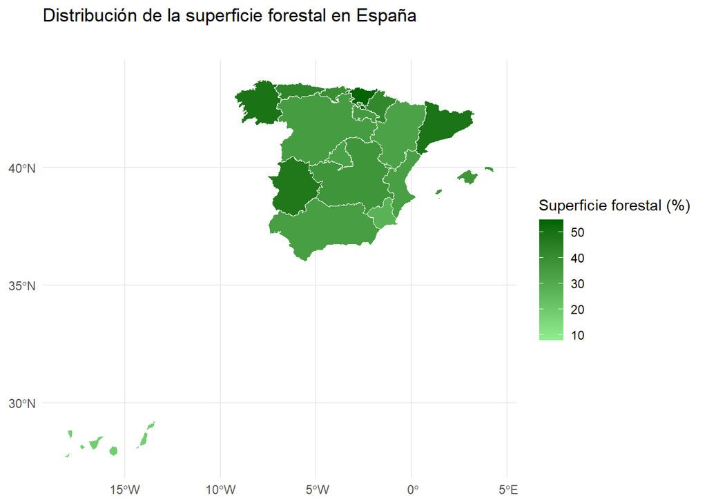

```r
library(ggplot2)

ggplot(mapa_final) +
  geom_sf(aes(fill = superficie_forestal), color = "white", linewidth = 0.3) +
  scale_fill_gradient(
    low = "lightgreen",
    high = "darkgreen",
    na.value = "grey90",
    name = "Superficie forestal (%)"
  ) +
  labs(
    title = "Distribución de la superficie forestal en España",
  ) +
  theme_minimal() +
    theme(
      plot.title = element_text(margin = margin(b = 25))
    )
```

### Prevalencia de transtornos mentales por comunidades autónomas

A continuación, se analiza la prevalencia de trastornos mentales en las distintas comunidades autónomas de España, con el objetivo de identificar las diferencias territoriales y entre sexos. Para ello, se representarán gráficamente los datos disponibles, permitiendo comparar los valores registrados en cada comunidad autónoma y observar las posibles diferencias entre hombres y mujeres.

#### Representación gráfica (Mapa temático)

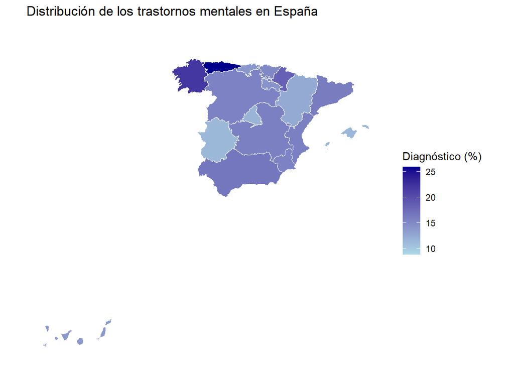

```r
library(ggplot2)

ggplot(mapa_mental) +
  geom_sf(aes(fill = total), color = "white", linewidth = 0.2) +
  scale_fill_gradient(
    low = "lightblue",
    high = "darkblue",
    name = "Diagnóstico (%)"
  ) +
  labs(
    title = "Distribución de los trastornos mentales en España",
  ) +
  theme_minimal() +
  theme(
    plot.title = element_text(margin = margin(b = 25)),
    axis.text = element_blank(),
    axis.ticks = element_blank(),
    panel.grid = element_blank()
  )
```

### Comparación del porcentaje de diagnósticos de trastorno mental según el sexo

Para comparar la prevalencia del diagnóstico de trastorno mental entre hombres y mujeres, se ha elaborado un gráfico de barras agrupadas que representa los porcentajes correspondientes a cada comunidad autónoma. Esta representación permite identificar las diferencias entre ambos sexos y observar la distribución territorial de los diagnósticos

#### Reorganizamos los datos de diagnóstico según el sexo

```r
sexo_grafico <- sexo_2017 %>%
  filter(comunidad != "España") %>%
  pivot_longer(
    cols = c(diagnostico_hombres, diagnostico_mujeres),
    names_to = "sexo",
    values_to = "prevalencia"
  ) %>%
  mutate(
    sexo = recode(
      sexo,
      diagnostico_hombres = "Hombres",
      diagnostico_mujeres = "Mujeres"
    )
  )
```

#### Representación gráfica (Gráfico de barras)

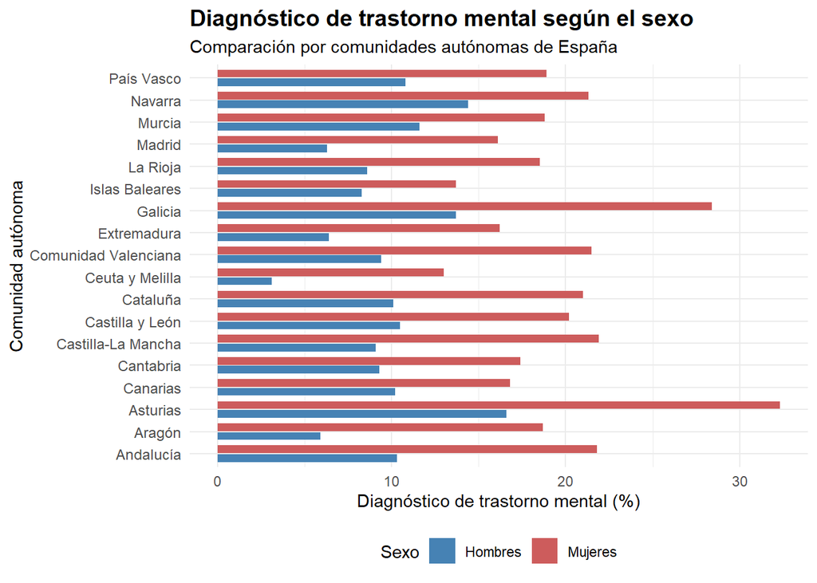

```r
ggplot(sexo_grafico,
       aes(x = comunidad, y = prevalencia, fill = sexo)) +

  geom_col(
    position = position_dodge(width = 0.8),
    width = 0.7
  ) +

  coord_flip() +

  scale_fill_manual(
    values = c(
      "Hombres" = "steelblue",
      "Mujeres" = "indianred"
    )
  ) +

  labs(
    title = "Diagnóstico de trastorno mental según el sexo",
    subtitle = "Comparación por comunidades autónomas de España",
    x = "Comunidad autónoma",
    y = "Diagnóstico de trastorno mental (%)",
    fill = "Sexo"
  ) +

  theme_minimal() +

  theme(
    plot.title = element_text(
      face = "bold",
      size = 14
    ),
    axis.text.y = element_text(size = 9),
    legend.position = "bottom"
  )
```

### Relación entre superficie forestal y salud mental

Posteriormente, se estudia la posible relación entre la superficie forestal y la prevalencia de trastornos mentales en las comunidades autónomas de España, con el objetivo de determinar si existe alguna asociación entre ambas variables. Para ello, se compararán gráficamente los datos obtenidos, permitiendo identificar posibles tendencias y analizar si una mayor superficie forestal se relaciona con una mayor o menor prevalencia de trastornos mentales.

#### Unimos los datos de superficie forestal y salud mental

```r
datos_relacion <- mapa_final %>%
  sf::st_drop_geometry() %>%
  select(NAME_1, superficie_forestal) %>%
  inner_join(
    mapa_mental %>%
      sf::st_drop_geometry() %>%
      select(NAME_1, total),
    by = "NAME_1"
  ) %>%
  filter(!is.na(superficie_forestal), !is.na(total))

datos_relacion
```

```
##                        NAME_1 superficie_forestal total
## 1                   Andalucía               34.34  16.5
## 2                      Aragón               32.76  12.4
## 3                   Cantabria               39.77  13.9
## 4          Castilla-La Mancha               37.41  15.8
## 5             Castilla y León               34.88  15.6
## 6                    Cataluña               49.12  16.0
## 7             Ceuta y Melilla               34.13   8.8
## 8             Ceuta y Melilla                7.83   8.8
## 9         Comunidad de Madrid               33.32  11.6
## 10 Comunidad Foral de Navarra               42.00  18.4
## 11       Comunidad Valenciana               34.01  15.8
## 12                Extremadura               47.63  11.3
## 13                    Galicia               49.45  21.9
## 14             Islas Baleares               37.27  11.4
## 15             Islas Canarias               18.48  13.7
## 16                   La Rioja               35.56  14.2
## 17                 País Vasco               54.89  15.1
## 18     Principado de Asturias               43.07  25.9
## 19           Región de Murcia               27.50  15.6
```

#### Representación gráfica (Gráfico de dispersión)

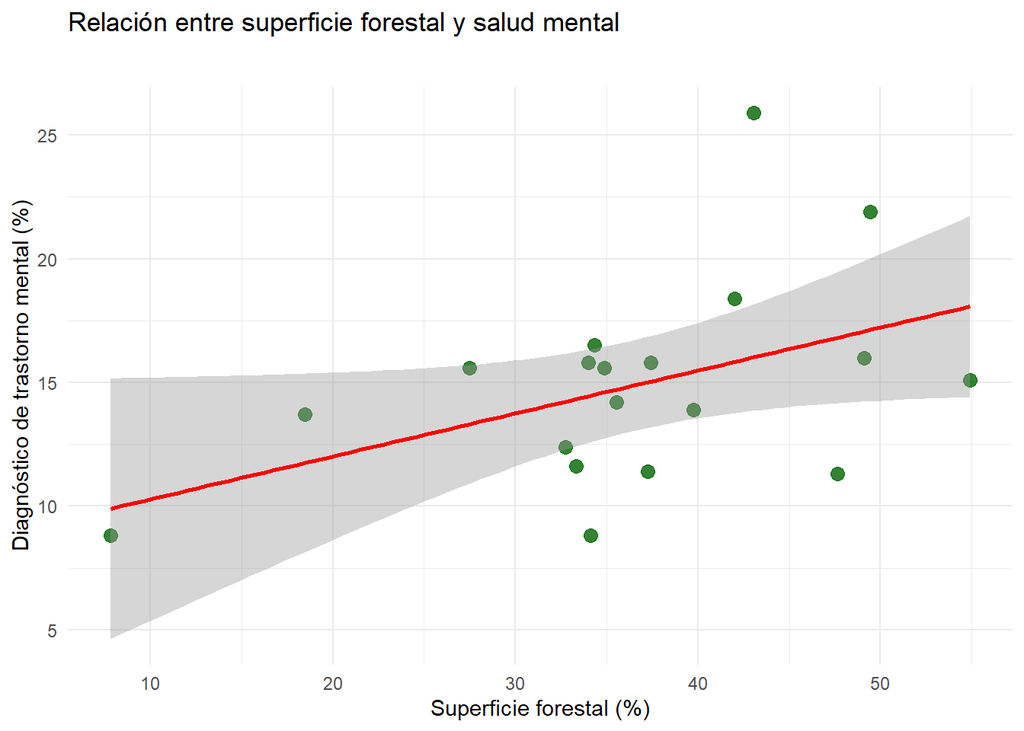

```r
ggplot(datos_relacion,
       aes(x = superficie_forestal, y = total)) +

  geom_point(
    color = "darkgreen",
    size = 3,
    alpha = 0.8
  ) +

  geom_smooth(
    method = "lm",
    formula = y ~ x,
    color = "red",
    se = TRUE
  ) +

  labs(
    title = "Relación entre superficie forestal y salud mental",
    x = "Superficie forestal (%)",
    y = "Diagnóstico de trastorno mental (%)"
  ) +

  theme_minimal() +
    theme(
      plot.title = element_text(margin = margin(b = 25))
    )
```

A partir del gráfico de dispersión, se observa una tendencia ligeramente positiva entre el porcentaje de superficie forestal y la prevalencia del diagnóstico de trastorno mental en las comunidades autónomas de España. Sin embargo, los puntos presentan una dispersión considerable, lo que indica que las diferencias territoriales no siguen un patrón claramente definido.

Además, se observa que algunas comunidades autónomas con una elevada proporción de superficie forestal también presentan porcentajes relativamente altos de diagnóstico de trastorno mental. Por tanto, los resultados no muestran una asociación visual negativa entre ambas variables, como inicialmente podría esperarse.

En conjunto, la representación gráfica sugiere que una mayor superficie forestal no está necesariamente relacionada con una menor prevalencia de diagnósticos de trastornos mentales. No obstante, esta observación debe interpretarse con cautela, ya que la salud mental depende de múltiples factores sociales, económicos, demográficos y ambientales que no se han considerado en este análisis.

### Patrones territoriales y posibles excepciones

Por último, se examinan los patrones territoriales observados en la relación entre la superficie forestal y la prevalencia de trastornos mentales, con el objetivo de identificar posibles excepciones a la tendencia general. Para ello, se analizarán las diferencias entre comunidades autónomas, prestando especial atención a aquellas que presenten valores alejados del comportamiento observado en el conjunto de los datos.

#### Representación gráfica (Gráfico de residuos)

```r
datos_residuos <- datos_relacion %>%
  group_by(NAME_1) %>%
  summarise(
    superficie_forestal = mean(superficie_forestal),
    total = first(total),
    .groups = "drop"
  )

modelo <- lm(total ~ superficie_forestal, data = datos_residuos)

datos_residuos <- datos_residuos %>%
  mutate(residuo = residuals(modelo))

datos_residuos
```

```
## # A tibble: 18 × 4
##    NAME_1                     superficie_forestal total residuo
##    <chr>                                    <dbl> <dbl>   <dbl>
##  1 Andalucía                                 34.3  16.5   1.82
##  2 Aragón                                    32.8  12.4  -2.00
##  3 Cantabria                                 39.8  13.9  -1.74
##  4 Castilla y León                           34.9  15.6   0.821
##  5 Castilla-La Mancha                        37.4  15.8   0.574
##  6 Cataluña                                  49.1  16    -1.30
##  7 Ceuta y Melilla                           21.0   8.8  -3.52
##  8 Comunidad Foral de Navarra                42    18.4   2.36
##  9 Comunidad Valenciana                      34.0  15.8   1.17
## 10 Comunidad de Madrid                       33.3  11.6  -2.90
## 11 Extremadura                               47.6  11.3  -5.73
## 12 Galicia                                   49.4  21.9   4.55
## 13 Islas Baleares                            37.3  11.4  -3.80
## 14 Islas Canarias                            18.5  13.7   1.82
## 15 La Rioja                                  35.6  14.2  -0.699
## 16 País Vasco                                54.9  15.1  -3.22
## 17 Principado de Asturias                    43.1  25.9   9.67
## 18 Región de Murcia                          27.5  15.6   2.13
```

#### Representación gráfica (Gráfico de residuos)

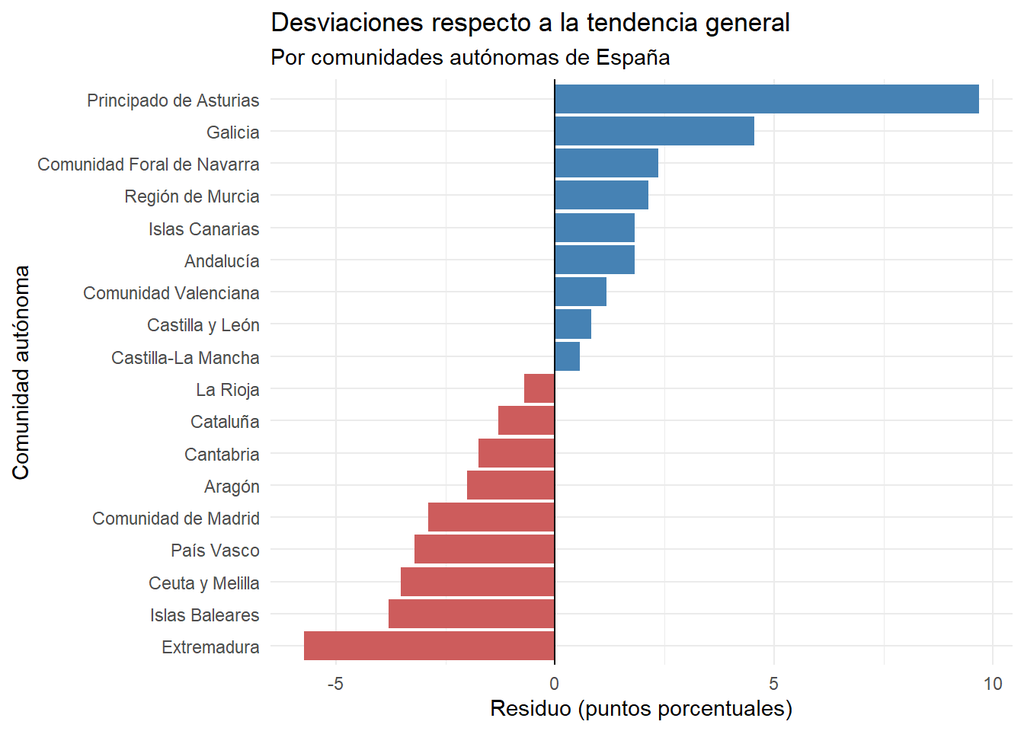

```r
ggplot(datos_residuos, aes(x = reorder(NAME_1, residuo),
                          y = residuo,
                          fill = residuo > 0)) +
  geom_col() +
  coord_flip() +
  geom_hline(yintercept = 0, color = "black") +
  scale_fill_manual(
    values = c("TRUE" = "steelblue", "FALSE" = "indianred"),
    guide = "none"
  ) +
  labs(
    title = "Desviaciones respecto a la tendencia general",
    subtitle = "Por comunidades autónomas de España",
    x = "Comunidad autónoma",
    y = "Residuo (puntos porcentuales)"
  ) +
  theme_minimal()
```

Como podemos observar, el gráfico muestra las desviaciones de cada comunidad autónoma respecto a la tendencia general entre la superficie forestal y el diagnóstico de trastornos mentales. Las barras azules representan valores superiores a los estimados, mientras que las rojas indican valores inferiores. En conjunto, se observan diferencias entre comunidades autónomas, lo que sugiere que la superficie forestal por sí sola no explica completamente las variaciones en los diagnósticos de trastornos mentales.

## Conclusiones

Los resultados obtenidos sugieren que no existe una relación clara entre una mayor superficie forestal y una mejor salud mental en las comunidades autónomas de España. Por tanto, no podemos afirmar que los territorios con mayor proporción de superficie forestal presenten necesariamente un menor porcentaje de diagnósticos de trastornos mentales.

Además, las diferencias observadas entre comunidades autónomas muestran que esta relación no sigue un patrón uniforme, por lo que no es posible establecer una conclusión general aplicable a todos los territorios.

En definitiva, aunque los espacios naturales pueden aportar beneficios para el bienestar de las personas, los resultados de nuestro análisis no permiten confirmar que una mayor superficie forestal se traduzca directamente en una mejor salud mental de la población.

## Referencias

- **Instituto Nacional de Estadística (INE).** (2018). *Superficie forestal como porcentaje de la superficie total, por comunidades autónomas*. Indicadores de los Objetivos de Desarrollo Sostenible (ODS). https://www.ine.es/jaxi/Tabla.htm?L=0&tpx=68563
- **Henares Montiel, J., Ruiz-Pérez, I. y Sordo, L.** (2020). *Salud mental en España y diferencias por sexo y por comunidades autónomas*. Gaceta Sanitaria, 34(2), 114-119. https://doi.org/10.1016/j.gaceta.2019.03.002
- **GADM.** *Database of Global Administrative Areas*. Datos cartográficos de los límites administrativos de España, obtenidos mediante el paquete `geodata` de R. https://gadm.org/